# ESM 244 Lab 3

Keene Morrow

1/23/2020

## Binary logistics regression: Penguins!

Read in data:

```r
gentoo <- read_csv("gentoo_lter.csv")
chinstrap <- read_csv("chinstrap_lter.csv")

# Use full_join() to merge them together (keeping everything)
penguins <- full_join(chinstrap, gentoo) %>%
  clean_names() %>%
  mutate(sex = str_to_lower(sex)) %>%
  filter(sex %in% c("male","female"))
```

Let’s take a look:

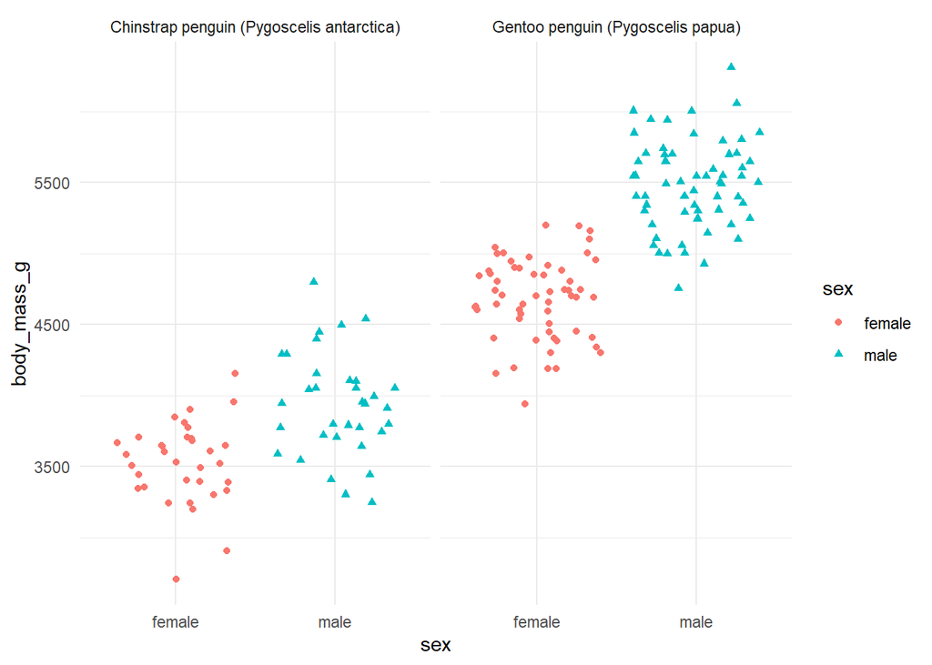

```r
ggplot(data = penguins, aes(x = sex, y = body_mass_g)) +
  geom_jitter(
    aes(color = sex,
        pch = sex) # changes point style
  ) +
  facet_wrap(~species) +
  theme_minimal()
```

Based on this, it seems pretty likely that we’d be able to identify whether a penguin is a Gentoo or Chinstrap if we know that it’s female and 5000g or male and 3000g. Harder if a 4900g male penguin or 4000g female penguin.

Code - Chinstrap penguins as 1 - Gentoo penguins as 0 using `case_when`

```r
penguin_bin <- penguins %>%
  mutate(
    sp_binary = case_when(
      species == "Chinstrap penguin (Pygoscelis antarctica)" ~ 1,
      species == "Gentoo penguin (Pygoscelis papua)" ~ 0
    )
  )
```

Binary logistic regression (Attempting to predict species based on sex and body mass)

```r
penguin_blr <- glm(sp_binary ~ sex + body_mass_g,
                   family = "binomial",
                   data = penguin_bin)

summary(penguin_blr)
```

```
##
## Call:
## glm(formula = sp_binary ~ sex + body_mass_g, family = "binomial",
##     data = penguin_bin)
##
## Deviance Residuals:
##      Min        1Q    Median        3Q       Max
## -1.80704  -0.01234  -0.00098   0.00258   1.93220
##
## Coefficients:
##              Estimate Std. Error z value Pr(>|z|)
## (Intercept) 62.916845  19.750712   3.186  0.00144 **
## sexmale     11.195233   3.959766   2.827  0.00470 **
## body_mass_g -0.015570   0.004868  -3.198  0.00138 **
## ---
## Signif. codes:  0 '***' 0.001 '**' 0.01 '*' 0.05 '.' 0.1 ' ' 1
##
## (Dispersion parameter for binomial family taken to be 1)
##
##     Null deviance: 245.150  on 186  degrees of freedom
## Residual deviance:  13.003  on 184  degrees of freedom
## AIC: 19.003
##
## Number of Fisher Scoring iterations: 10
```

Check out the estimates in the summary above. Remember that the estimates of coefficients are the log odds. The coefficient is the impact on the probability that a penguin is a Chinstrap.

Let’s make some predictions for penguins! (this is pretty close to classification)

1. What is the probability that a penguin is a chinstrap penguin if it weighs 4500g and is male?

```r
# models like new data to be presented to them as a shiny new data frame
df_m4500 <- data.frame(sex = "male", body_mass_g = 4500) # variable names and contents must match the original data frame

# find log odds of this penguin being chinstrap:
m4500_logodds <- predict(penguin_blr, newdata = df_m4500, type = "link")

# But was does 4.05 mean?
# Let's make it give us a probability

m4500_logodds <- predict(penguin_blr, newdata = df_m4500, type = "response")

# So, 98.3% chance that it's a Chinstrap penguin
```

2. What is the probability that a penguin is a chinstrap penguin if it weighs 4000g and female? (this is right on the edge of the two groups)

```r
df_f4000 <- data.frame(sex = "female", body_mass_g = 4000)

f4000_logodds <-  predict(penguin_blr, newdata = df_f4000, type = "response")
# 65.4% chance that it's a Chinstrap penguin :)
```